# ADVERTISEMENTS ANALYSIS

- This is a R Markdown notebook, and can be viewed as a html script. Please do not view directly on github.

# Data Scientist

- Ryan Mburu

# Question Definition

A customer working in the crypto market is looking to deeply understand her audience and how they interact with ads posted on her website. We are to assist her understand which demographic of her viewers interact with ads the most/least so as to help her make better decisions moving foward.

# Metric of Success

Perform data cleaning and Exploratory data Analysis so as to get insights on the audience and their interad]ctions with the advertisements

# Relevance of the data

It is relevant. Trust me.

# Loading the dataset

```r
library('data.table')
library(tidyverse)
ads <- read.csv('~/Documents/DS-Projects/R/advertisement recommendation/advertising.csv')

#print first 6 rows

head(ads)
```

```
##   Daily.Time.Spent.on.Site Age Area.Income Daily.Internet.Usage
## 1                    68.95  35    61833.90               256.09
## 2                    80.23  31    68441.85               193.77
## 3                    69.47  26    59785.94               236.50
## 4                    74.15  29    54806.18               245.89
## 5                    68.37  35    73889.99               225.58
## 6                    59.99  23    59761.56               226.74
##                           Ad.Topic.Line           City Male    Country
## 1    Cloned 5thgeneration orchestration    Wrightburgh    0    Tunisia
## 2    Monitored national standardization      West Jodi    1      Nauru
## 3      Organic bottom-line service-desk       Davidton    0 San Marino
## 4 Triple-buffered reciprocal time-frame West Terrifurt    1      Italy
## 5         Robust logistical utilization   South Manuel    0    Iceland
## 6       Sharable client-driven software      Jamieberg    1     Norway
##             Timestamp Clicked.on.Ad
## 1 2016-03-27 00:53:11             0
## 2 2016-04-04 01:39:02             0
## 3 2016-03-13 20:35:42             0
## 4 2016-01-10 02:31:19             0
## 5 2016-06-03 03:36:18             0
## 6 2016-05-19 14:30:17             0
```

```r
# Size of the dataset
print(nrow(ads))
```

```
## [1] 1000
```

```r
print(ncol(ads))
```

```
## [1] 10
```

the dataset has 1000 rows and 10 columns

# Data Cleaning

## Missing values

```r
# Checking for missing values and handling them if present

colSums(is.na(ads))
```

```
## Daily.Time.Spent.on.Site                      Age              Area.Income
##                        0                        0                        0
##     Daily.Internet.Usage            Ad.Topic.Line                     City
##                        0                        0                        0
##                     Male                  Country                Timestamp
##                        0                        0                        0
##            Clicked.on.Ad
##                        0
```

No column has any null values

## Duplicates

```r
colSums(ads[duplicated(ads)])
```

```
## numeric(0)
```

No duplicates

## Outliers

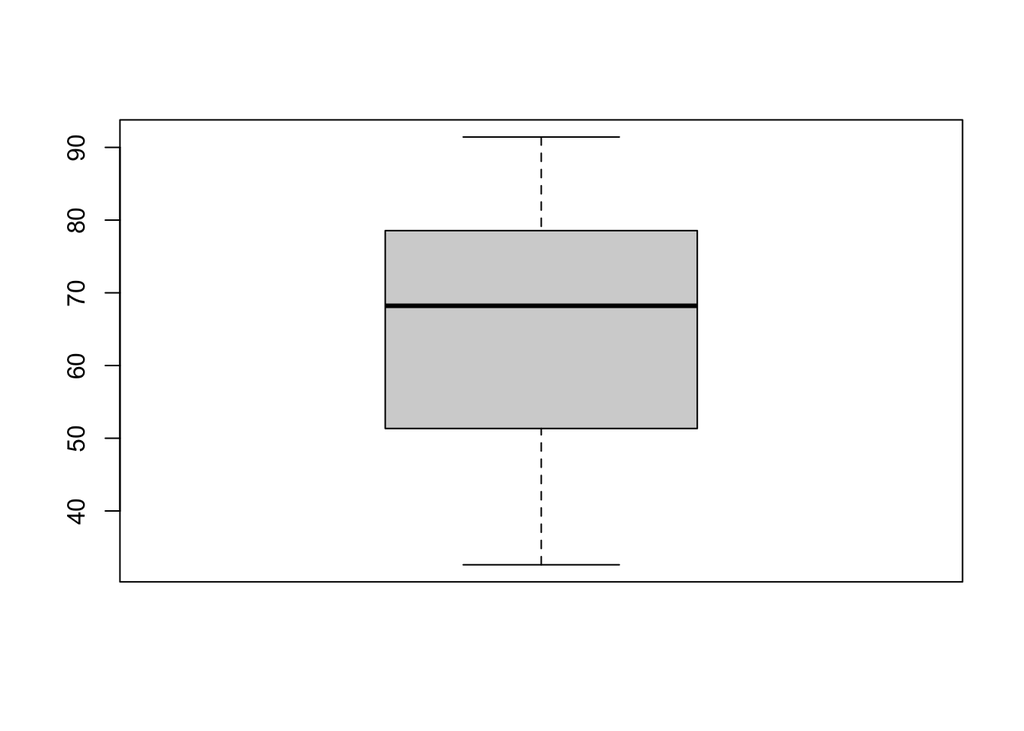

```r
# Will use a boxplot

# 1. Time spent on site

boxplot(ads$Daily.Time.Spent.on.Site)
```

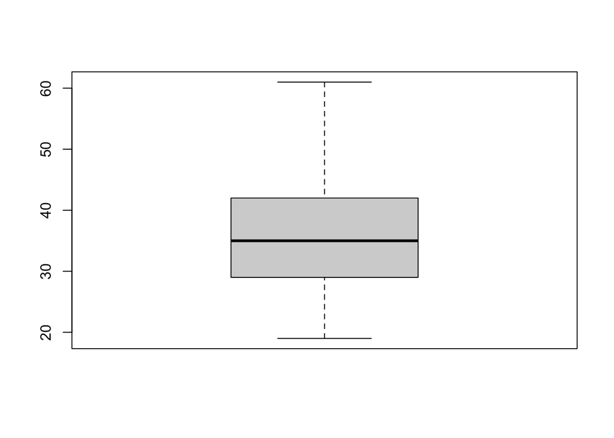

```r
# age of the customers
boxplot(ads$Age)
```

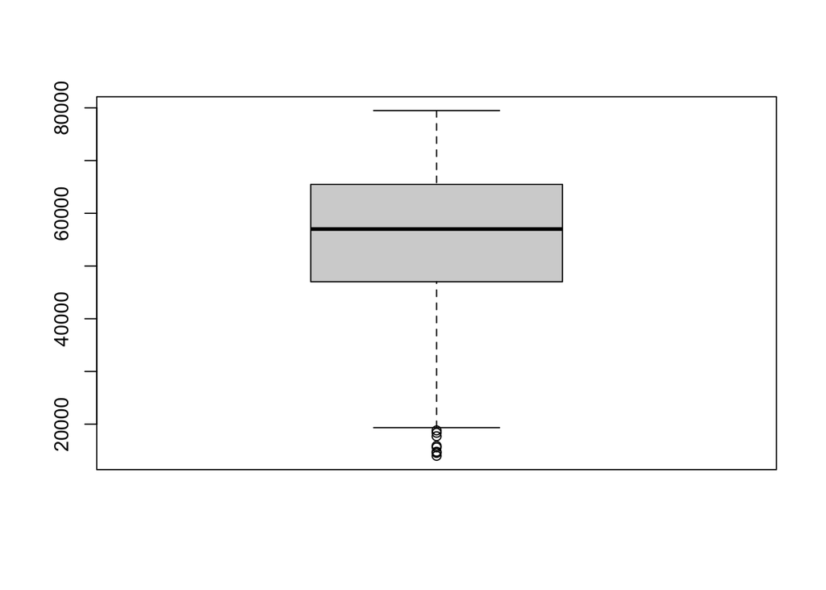

```r
# income
boxplot(ads$Area.Income)
```

there are outliers, and will be dropped

```r
#Outliers will be saved in a vector

outliers <- boxplot.stats(ads$Area.Income)$out
outliers
```

```
## [1] 17709.98 18819.34 15598.29 15879.10 14548.06 13996.50 14775.50 18368.57
```

```r
# Dropping them from our data
new_ads <- ads
new_ads
```

```
##      Daily.Time.Spent.on.Site Age Area.Income Daily.Internet.Usage
## 1                       68.95  35    61833.90               256.09
## 2                       80.23  31    68441.85               193.77
## 3                       69.47  26    59785.94               236.50
## 4                       74.15  29    54806.18               245.89
## 5                       68.37  35    73889.99               225.58
## 6                       59.99  23    59761.56               226.74
## 7                       88.91  33    53852.85               208.36
## 8                       66.00  48    24593.33               131.76
## 9                       74.53  30    68862.00               221.51
## 10                      69.88  20    55642.32               183.82
## 11                      47.64  49    45632.51               122.02
## 12                      83.07  37    62491.01               230.87
## 13                      69.57  48    51636.92               113.12
## 14                      79.52  24    51739.63               214.23
```

[output cut: 4990 more lines]

```r
new_ads <- new_ads[-which(new_ads$Area.Income %in% outliers),]
new_ads
```

```
##      Daily.Time.Spent.on.Site Age Area.Income Daily.Internet.Usage
## 1                       68.95  35    61833.90               256.09
## 2                       80.23  31    68441.85               193.77
## 3                       69.47  26    59785.94               236.50
## 4                       74.15  29    54806.18               245.89
## 5                       68.37  35    73889.99               225.58
## 6                       59.99  23    59761.56               226.74
## 7                       88.91  33    53852.85               208.36
## 8                       66.00  48    24593.33               131.76
## 9                       74.53  30    68862.00               221.51
## 10                      69.88  20    55642.32               183.82
## 11                      47.64  49    45632.51               122.02
## 12                      83.07  37    62491.01               230.87
## 13                      69.57  48    51636.92               113.12
## 14                      79.52  24    51739.63               214.23
```

[output cut: 4950 more lines]

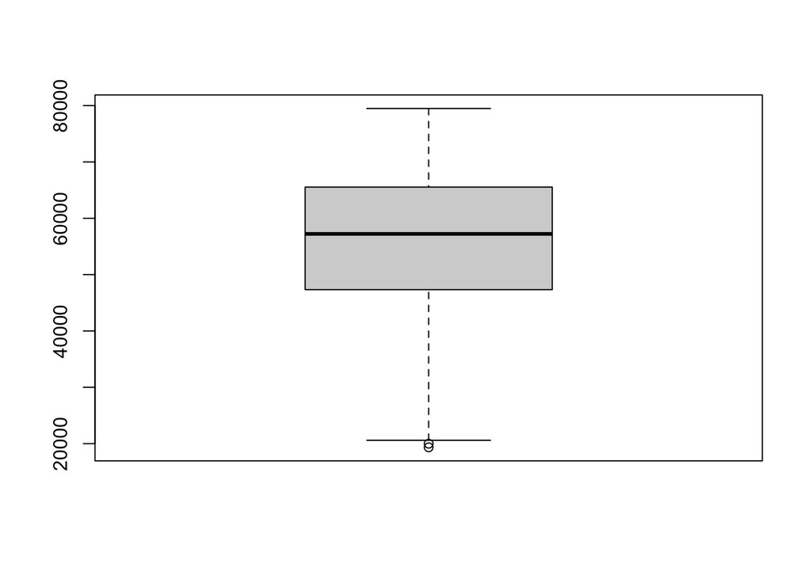

```r
boxplot(new_ads$Area.Income)
```

The outliers are dropped, as now they are way less than the previous boxplot

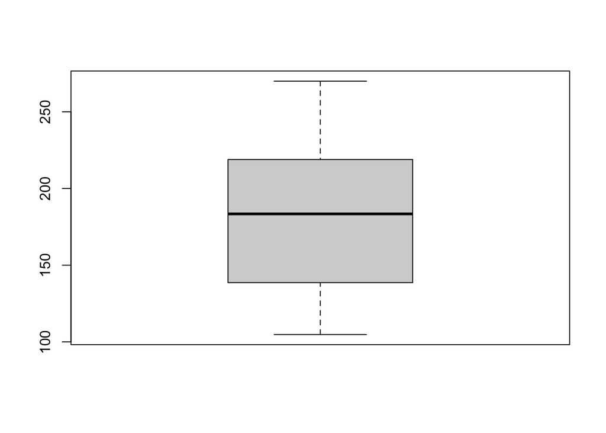

```r
# outliers in internet usage column
boxplot(new_ads$Daily.Internet.Usage)
```

# EXPLORATORY DATA ANALYSIS

# Univariate Analysis

```r
# get the dataset for numeric data only

numeric_ads <- select(new_ads, Daily.Time.Spent.on.Site, Age, Area.Income,Daily.Internet.Usage)
numeric_ads
```

```
##      Daily.Time.Spent.on.Site Age Area.Income Daily.Internet.Usage
## 1                       68.95  35    61833.90               256.09
## 2                       80.23  31    68441.85               193.77
## 3                       69.47  26    59785.94               236.50
## 4                       74.15  29    54806.18               245.89
## 5                       68.37  35    73889.99               225.58
## 6                       59.99  23    59761.56               226.74
## 7                       88.91  33    53852.85               208.36
## 8                       66.00  48    24593.33               131.76
## 9                       74.53  30    68862.00               221.51
## 10                      69.88  20    55642.32               183.82
## 11                      47.64  49    45632.51               122.02
## 12                      83.07  37    62491.01               230.87
## 13                      69.57  48    51636.92               113.12
## 14                      79.52  24    51739.63               214.23
```

[output cut: 978 more lines]

```r
# Mean for all numeric data
apply(numeric_ads, 2, mean)
```

```
## Daily.Time.Spent.on.Site                      Age              Area.Income
##                 65.03979                 35.98286              55312.80720
##     Daily.Internet.Usage
##                179.98504
```

```r
# Median
apply(numeric_ads, 2, median)
```

```
## Daily.Time.Spent.on.Site                      Age              Area.Income
##                   68.390                   35.000                57228.185
##     Daily.Internet.Usage
##                  183.425
```

```r
# Minimum values
apply(numeric_ads, 2, min)
```

```
## Daily.Time.Spent.on.Site                      Age              Area.Income
##                    32.60                    19.00                 19345.36
##     Daily.Internet.Usage
##                   104.78
```

```r
# Maximum values
apply(numeric_ads, 2, max)
```

```
## Daily.Time.Spent.on.Site                      Age              Area.Income
##                    91.43                    61.00                 79484.80
##     Daily.Internet.Usage
##                   269.96
```

```r
# range of values
apply(numeric_ads, 2, range)
```

```
##      Daily.Time.Spent.on.Site Age Area.Income Daily.Internet.Usage
## [1,]                    32.60  19    19345.36               104.78
## [2,]                    91.43  61    79484.80               269.96
```

```r
# Quantiles
apply(numeric_ads, 2, quantile)
```

```
##      Daily.Time.Spent.on.Site Age Area.Income Daily.Internet.Usage
## 0%                     32.600  19    19345.36             104.7800
## 25%                    51.285  29    47332.82             138.6475
## 50%                    68.390  35    57228.18             183.4250
## 75%                    78.585  42    65518.96             218.8425
## 100%                   91.430  61    79484.80             269.9600
```

```r
# Variance
apply(numeric_ads, 2, var)
```

```
## Daily.Time.Spent.on.Site                      Age              Area.Income
##             2.528609e+02             7.745379e+01             1.691376e+08
##     Daily.Internet.Usage
##             1.938785e+03
```

```r
# Standard deviation
apply(numeric_ads, 2, sd)
```

```
## Daily.Time.Spent.on.Site                      Age              Area.Income
##                15.901600                 8.800784             13005.290554
##     Daily.Internet.Usage
##                44.031632
```

## Distributions

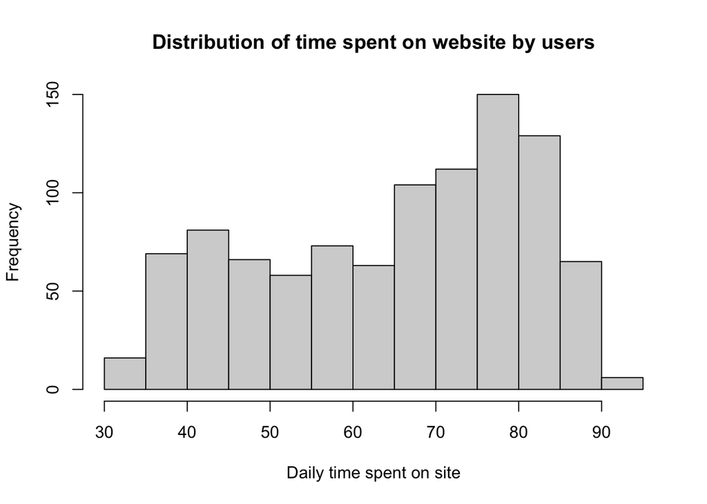

```r
# Distribution of time spent on the website

hist(numeric_ads$Daily.Time.Spent.on.Site, xlab = 'Daily time spent on site', main = 'Distribution of time spent on website by users')
```

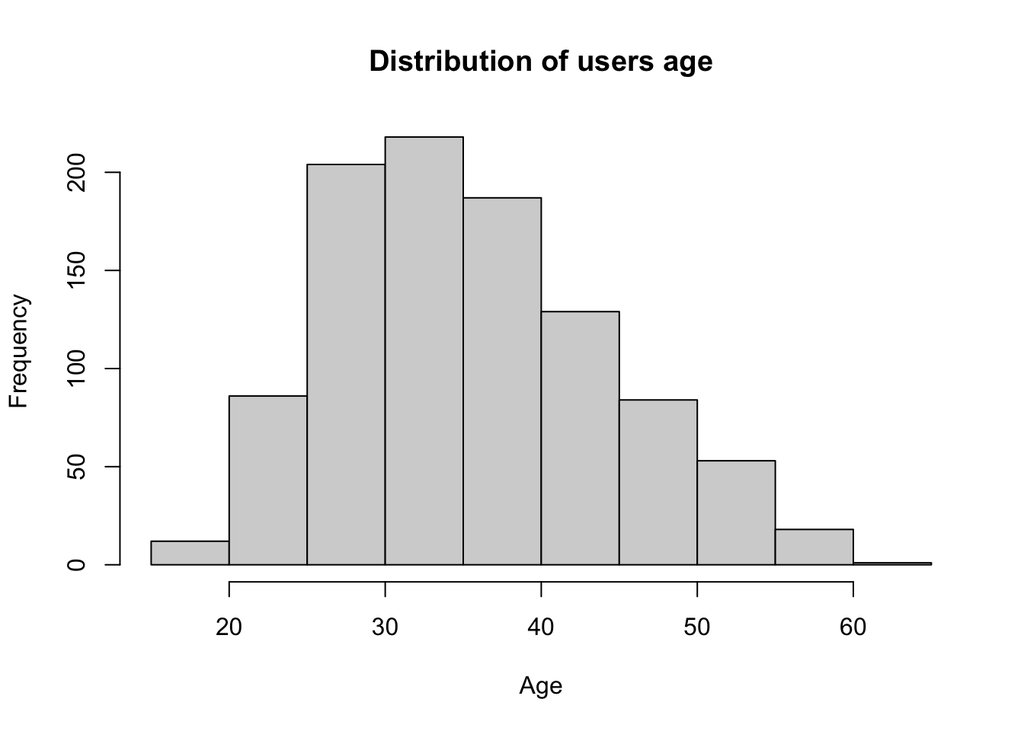

```r
# Distribution of the age groups
hist(numeric_ads$Age, xlab = 'Age', main = 'Distribution of users age')
```

Age is normally distributed

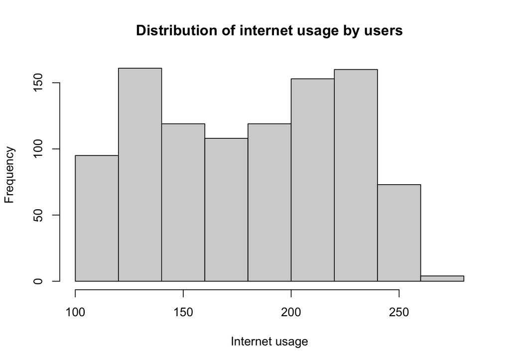

```r
hist(numeric_ads$Daily.Internet.Usage, xlab = 'Internet usage', main = 'Distribution of internet usage by users')
```

Not a normal distribution

# Multivariate Analysis

will check for 1. Covarience 2. Correlation 3. relationship vetween variables using scatterplots

## 1. Time spent and age

```r
# Covarience between time spent on the site and age

cov((numeric_ads$Daily.Time.Spent.on.Site), (numeric_ads$Age))
```

```
## [1] -46.5009
```

Negative value, indicating a negative relationship between the two

```r
# Correlation of the two
cor((numeric_ads$Daily.Time.Spent.on.Site), (numeric_ads$Age))
```

```
## [1] -0.3322762
```

A negative correlation as well

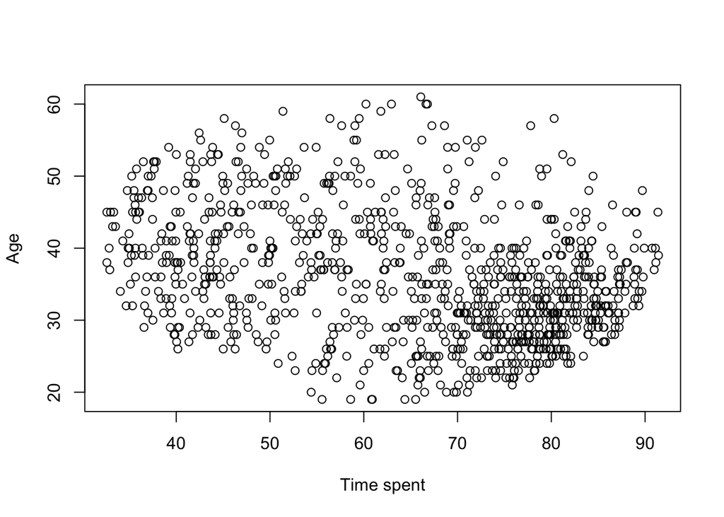

```r
# scatterplot
plot((numeric_ads$Daily.Time.Spent.on.Site), (numeric_ads$Age), xlab = 'Time spent', ylab = 'Age')
```

## 1. Daily internet usage and age

```r
# Covarience between daily net usage on the site and age

cov((numeric_ads$Daily.Internet.Usage), (numeric_ads$Age))
```

```
## [1] -142.5798
```

Negative relationship.

```r
# Correlation between daily net usage on the site and age

cor((numeric_ads$Daily.Internet.Usage), (numeric_ads$Age))
```

```
## [1] -0.3679358
```

Low correlation

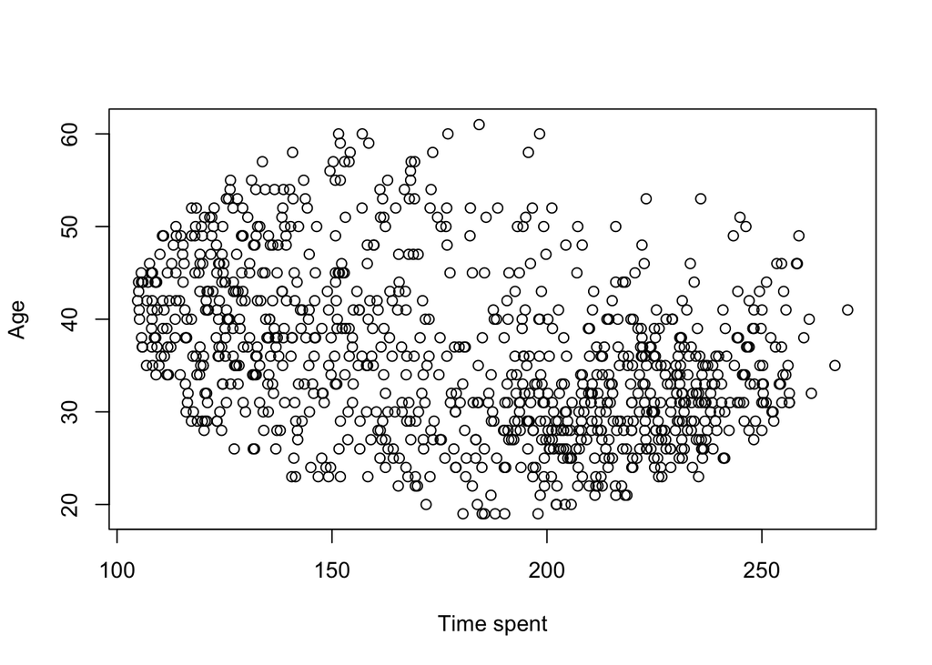

```r
# scatterplot
plot((numeric_ads$Daily.Internet.Usage), (numeric_ads$Age), xlab = 'Time spent', ylab = 'Age')
```

# Bivariate analysis with the label

```r
clicks <- table(new_ads$Clicked.on.Ad)
clicks
```

```
##
##   0   1
## 500 492
```

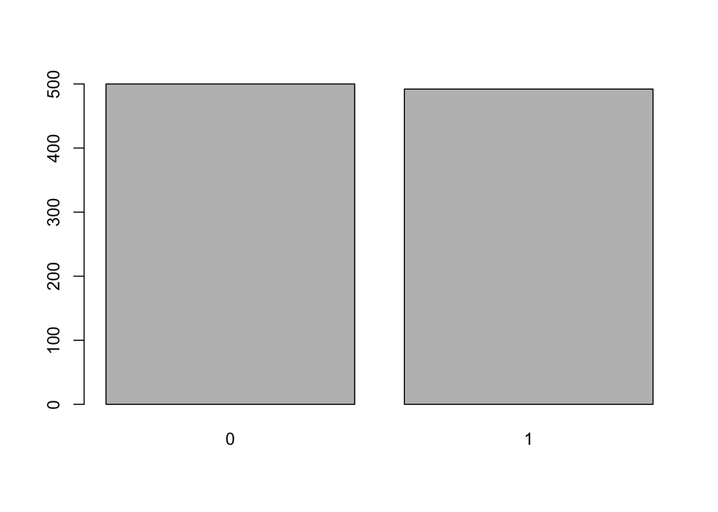

```r
barplot(
  clicks
)
```

There is a level amount of users who click the ads and those who dont.

```r
# Analysis of people who click on the ads
ad_clickers <- new_ads[which(new_ads$Clicked.on.Ad == 1),]
ad_clickers
```

```
##      Daily.Time.Spent.on.Site Age Area.Income Daily.Internet.Usage
## 8                       66.00  48    24593.33               131.76
## 11                      47.64  49    45632.51               122.02
## 13                      69.57  48    51636.92               113.12
## 15                      42.95  33    30976.00               143.56
## 16                      63.45  23    52182.23               140.64
## 17                      55.39  37    23936.86               129.41
## 19                      54.70  36    31087.54               118.39
## 20                      74.58  40    23821.72               135.51
## 23                      41.49  52    32635.70               164.83
## 25                      41.39  41    68962.32               167.22
## 27                      48.53  28    38067.08               134.14
## 28                      51.95  52    58295.82               129.23
## 29                      70.20  34    32708.94               119.20
## 33                      59.05  57    25583.29               169.23
```

[output cut: 2450 more lines]

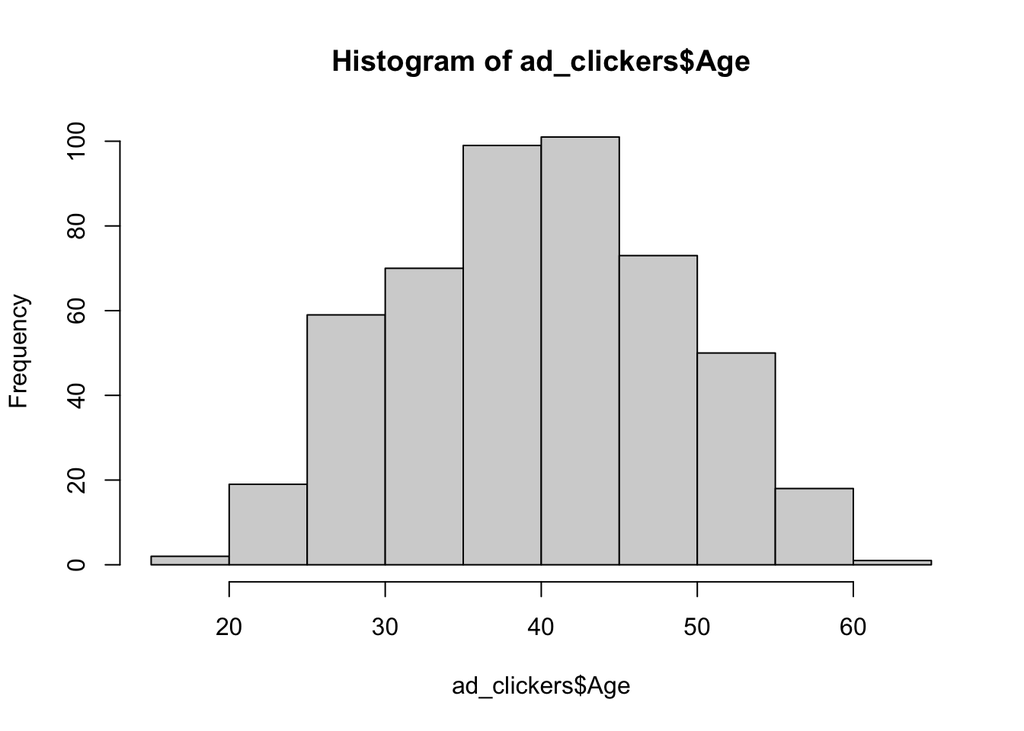

```r
# Most popular age group of people clicking on ads
hist(ad_clickers$Age)
```

30 - 50 year olds click on the most ads

```r
#Most popular nations
country_table <- table(ad_clickers$Country)
country_table
```

```
##
##                                         Afghanistan
##                                                   5
##                                             Albania
##                                                   4
##                                             Algeria
##                                                   2
##                                      American Samoa
##                                                   3
##                                             Andorra
##                                                   2
##                                              Angola
##                                                   1
##                                            Anguilla
##                                                   3
##        Antarctica (the territory South of 60 deg S)
##                                                   2
##                                 Antigua and Barbuda
##                                                   4
##                                           Argentina
##                                                   1
##                                             Armenia
##                                                   1
##                                           Australia
##                                                   7
##                                             Austria
##                                                   1
##                                             Bahamas
##                                                   4
##                                             Bahrain
##                                                   2
##                                          Bangladesh
##                                                   2
##                                            Barbados
##                                                   2
##                                             Belarus
##                                                   3
##                                             Belgium
##                                                   2
##                                              Belize
```

[output cut: 374 more lines]

```
##                                                   1
##                                           Venezuela
##                                                   3
##                                             Vietnam
##                                                   2
##                                   Wallis and Futuna
##                                                   1
##                                      Western Sahara
##                                                   4
##                                               Yemen
##                                                   2
##                                              Zambia
##                                                   3
##                                            Zimbabwe
##                                                   4
```

# Conclusion